# Deannevr.Assignment04

Deannevr

20/04/2024

Data source:

- https://github.com/rfordatascience/tidytuesday/tree/master/data/2022/2022-01-18
- https://flavorsofcacao.com/chocolate_database.html

# Reading the data

```r
raw_data = read.csv('C:/Users/Deanne/Desktop/Term 4/SUBJECTS/STATS PROGRAMMING/chocolate.csv')
N = nrow(raw_data)
raw_data = raw_data %>% mutate(key = 1:N) # adding a unique ID to all rows
```

# EDA

```r
head(raw_data)
```

```
##    ref company_manufacturer company_location review_date country_of_bean_origin
## 1 2454                 5150           U.S.A.        2019               Tanzania
## 2 2458                 5150           U.S.A.        2019     Dominican Republic
## 3 2454                 5150           U.S.A.        2019             Madagascar
## 4 2542                 5150           U.S.A.        2021                   Fiji
## 5 2546                 5150           U.S.A.        2021              Venezuela
## 6 2546                 5150           U.S.A.        2021                 Uganda
##   specific_bean_origin_or_bar_name cocoa_percent ingredients
## 1            Kokoa Kamili, batch 1           76%    3- B,S,C
## 2                  Zorzal, batch 1           76%    3- B,S,C
## 3           Bejofo Estate, batch 1           76%    3- B,S,C
## 4            Matasawalevu, batch 1           68%    3- B,S,C
## 5            Sur del Lago, batch 1           72%    3- B,S,C
## 6         Semuliki Forest, batch 1           80%    3- B,S,C
##      most_memorable_characteristics rating key
## 1         rich cocoa, fatty, bready   3.25   1
## 2            cocoa, vegetal, savory   3.50   2
## 3      cocoa, blackberry, full body   3.75   3
## 4               chewy, off, rubbery   3.00   4
## 5 fatty, earthy, moss, nutty,chalky   3.00   5
## 6 mildly bitter, basic cocoa, fatty   3.25   6
```

```r
summary(raw_data)
```

```
##       ref       company_manufacturer company_location    review_date
##  Min.   :   5   Length:2530          Length:2530        Min.   :2006
##  1st Qu.: 802   Class :character     Class :character   1st Qu.:2012
##  Median :1454   Mode  :character     Mode  :character   Median :2015
##  Mean   :1430                                           Mean   :2014
##  3rd Qu.:2079                                           3rd Qu.:2018
##  Max.   :2712                                           Max.   :2021
##  country_of_bean_origin specific_bean_origin_or_bar_name cocoa_percent
##  Length:2530            Length:2530                      Length:2530
##  Class :character       Class :character                 Class :character
##  Mode  :character       Mode  :character                 Mode  :character
##
##
##
##  ingredients        most_memorable_characteristics     rating
##  Length:2530        Length:2530                    Min.   :1.000
##  Class :character   Class :character               1st Qu.:3.000
##  Mode  :character   Mode  :character               Median :3.250
##                                                    Mean   :3.196
##                                                    3rd Qu.:3.500
##                                                    Max.   :4.000
##       key
##  Min.   :   1.0
##  1st Qu.: 633.2
##  Median :1265.5
##  Mean   :1265.5
##  3rd Qu.:1897.8
##  Max.   :2530.0
```

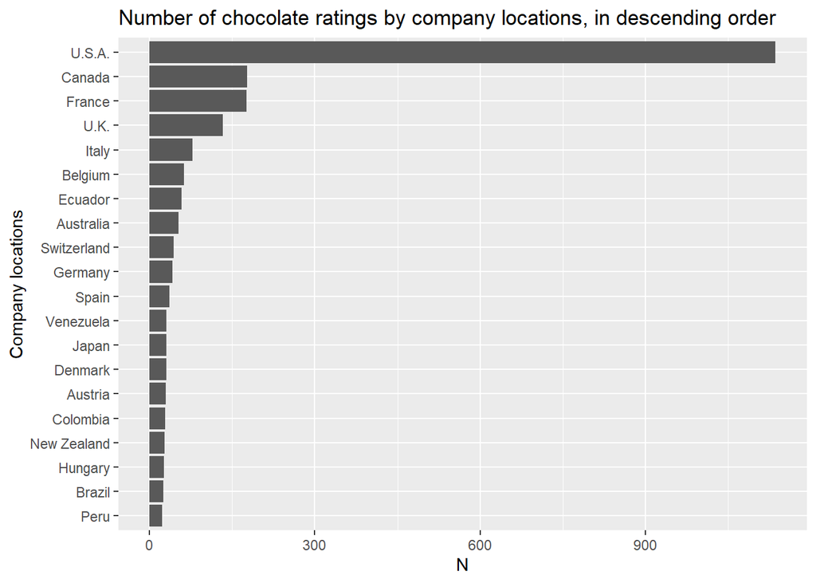

```r
tmp = raw_data %>%
  count(company_location) %>%
  arrange(desc(n)) %>%
  top_n(20)

tmp = raw_data %>% inner_join(tmp, by = join_by(company_location)) %>% select(!n)

tmp %>% ggplot(aes(x=reorder(company_location, company_location, length))) +
  geom_bar() +
  coord_flip() +
  labs(title="Number of chocolate ratings by company locations, in descending order", x = "Company locations", y = "N")
```

```r
length(unique(raw_data$company_location))
```

```
## [1] 67
```

Can see that the chocolate market represented in the data set are largely dominated by the U.S. Keep in mind, that it only displayed the top 20 values for chart clarity, however, this is less than half of the unique values from the data set for company locations.

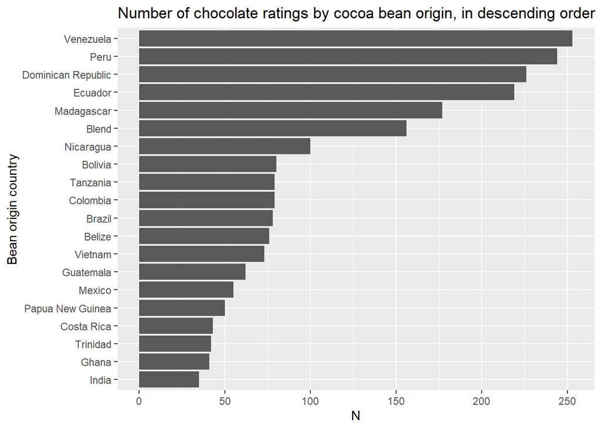

```r
tmp = raw_data %>%
  count(country_of_bean_origin) %>%
  arrange(desc(n)) %>%
  top_n(20)

tmp = raw_data %>% inner_join(tmp, by = join_by(country_of_bean_origin)) %>% select(!n)

tmp %>% ggplot(aes(x=reorder(country_of_bean_origin, country_of_bean_origin, length))) +
  geom_bar() +
  coord_flip() +
  labs(title="Number of chocolate ratings by cocoa bean origin, in descending order", x = "Bean origin country", y = "N")
```

```r
length(unique(raw_data$country_of_bean_origin))
```

```
## [1] 62
```

```r
nrow(tmp) / nrow(raw_data)
```

```
## [1] 0.856917
```

While this data shows less of a drastic drop from a specific value compared to the previous plot with company location, can also see that these top 20 origins of cocoa beans populate 85% of the data set, which also means an uneven distribution.

# Data cleaning and feature engineering

Both data cleaning and feature engineering are core parts of any data science project. Here, the data set mostly contains a set of nominal type variables like manufacturer name, or chocolate characteristics. Nominal variables can be one-hot encoded to map them to numerical values without introducing any kind of ordering between the values variable. One must be careful, however, with one-hot encoding as if the number of unique values is high, it can introduce a vast amount of dummy variables. To address this, an aggregation is done on many of these variables:

- both manufacturer country and cocoa bean origin are first aggregated up to continent level, using the “countrycode” library. This leaves at most 5 different values, which are one-hot encoded in to dummy variables, all starting with either with prefix “company_” referring to the chocolate manufacturer or “origin_” where the beans were grown.

```r
data = raw_data %>%

  # select only relevant columns: dropping ref and manufacturer, adding key as unique identifier
  select(key,
         review_date,
         company_location,
         country_of_bean_origin,
         cocoa_percent,
         ingredients,
         most_memorable_characteristics,
         rating) %>%

  # renaming
  rename(year = review_date,
         location = company_location,
         origin = country_of_bean_origin,
         cocoa = cocoa_percent,
         characteristics = most_memorable_characteristics) %>%

  # cocoa % to integers
  mutate(cocoa = as.numeric(sub("%", "", cocoa))) %>%


  # aggregating manufacturer country to continent level
  mutate(location = countrycode(location, origin = "country.name", destination = "continent")) %>%
  mutate(location = replace_na(location, "Europe")) %>% # handling some missed data Amsterdam, Scotland, Wales
  mutate(value = 1) %>% spread(location, value,  fill = 0) %>%
  rename(company_Africa = Africa,
         company_Americas = Americas,
         company_Asia = Asia,
         company_Europe = Europe,
         company_Oceania = Oceania) %>%

  # repeat the same aggregation on cocoa bean origin
  mutate(continent = countrycode(origin, origin = "country.name", destination = "continent"))  %>%
  mutate(continent = if_else(origin == "Principe", "Africa", continent)) %>%
  mutate(continent = if_else(origin == "Sulawesi", "Oceania", continent)) %>%
  mutate(continent = if_else(origin == "Sumatra", "Oceania", continent)) %>%
  filter(origin != "Blend") %>%
  select(!origin) %>%
  mutate(value = 1) %>% spread(continent, value,  fill = 0) %>%
  rename(origin_Africa = Africa,
         origin_Americas = Americas,
         origin_Asia = Asia,
         # origin_Europe = Europe, # Europe is not in the manufacturers
         origin_Oceania = Oceania)

head(data)
```

```
##   key year cocoa ingredients                   characteristics rating
## 1   1 2019    76    3- B,S,C         rich cocoa, fatty, bready   3.25
## 2   2 2019    76    3- B,S,C            cocoa, vegetal, savory   3.50
## 3   3 2019    76    3- B,S,C      cocoa, blackberry, full body   3.75
## 4   4 2021    68    3- B,S,C               chewy, off, rubbery   3.00
## 5   5 2021    72    3- B,S,C fatty, earthy, moss, nutty,chalky   3.00
## 6   6 2021    80    3- B,S,C mildly bitter, basic cocoa, fatty   3.25
##   company_Africa company_Americas company_Asia company_Europe company_Oceania
## 1              0                1            0              0               0
## 2              0                1            0              0               0
## 3              0                1            0              0               0
## 4              0                1            0              0               0
## 5              0                1            0              0               0
## 6              0                1            0              0               0
##   origin_Africa origin_Americas origin_Asia origin_Oceania
## 1             1               0           0              0
## 2             0               1           0              0
## 3             1               0           0              0
## 4             0               0           0              1
## 5             0               1           0              0
## 6             1               0           0              0
```

To utilize a characteristics column, sentiment analysis was exploited from the “tidytext” library. This way can have scoring to critiques written assessment. For a given chocolate, these ratings were averaged back to get a single score. Also, the number of characteristics given were also saved in a column.

```r
library(tidytext)

# temporary data table, adding count of characteristics to entries
tmp = data %>%
  select(key, characteristics) %>%
  separate_longer_delim(characteristics, ", ") %>%
  left_join(get_sentiments("afinn"), join_by(characteristics == word)) %>% rename(sentiment = value) %>% mutate(sentiment = replace_na(sentiment, 0)) %>%
  group_by(key) %>% summarise(count_characteristics = n(), average_characteristics_rating = round(mean(sentiment), 4))

data = data %>% inner_join(tmp) %>% select(!characteristics)

head(tmp)
```

```
## # A tibble: 6 × 3
##     key count_characteristics average_characteristics_rating
##   <int>                 <int>                          <dbl>
## 1     1                     3                              0
## 2     2                     3                              0
## 3     3                     3                              0
## 4     4                     3                              0
## 5     5                     4                              0
## 6     6                     3                              0
```

Lastly, similar transformation is done on the additional ingredients columns. Each ingredient were extracted into separate, binary columns, which have value 1 if the given ingredient is added to the chocolate. The total number of additional ingredients were also saved.

```r
library(stringr)

tmp = data %>%
  select(key, ingredients) %>%
  mutate(ingredients = str_replace_all(ingredients, "\\d-", "")) %>%
  separate_longer_delim(ingredients, ",") %>%
  mutate(ingredients = str_replace_all(ingredients, " B", "B")) %>%
  mutate(value = 1) %>% spread(ingredients, value,  fill = 0) %>%
  select(!V1) %>%
  rename(
    contains_beans = B,
    contains_cocoa_butter = C,
    contains_lecithin = L,
    contains_sugar = S,
    contains_sweetener = "S*",
    contains_salt = Sa,
    contains_vanilla = V) %>%
  mutate(count_additional_ingredients = contains_beans + contains_cocoa_butter + contains_lecithin + contains_sugar + contains_sweetener + contains_salt + contains_vanilla)

data = data %>% inner_join(tmp, join_by(key)) %>% select(!ingredients)

head(tmp)
```

```
##   key contains_beans contains_cocoa_butter contains_lecithin contains_sugar
## 1   1              1                     1                 0              1
## 2   2              1                     1                 0              1
## 3   3              1                     1                 0              1
## 4   4              1                     1                 0              1
## 5   5              1                     1                 0              1
## 6   6              1                     1                 0              1
##   contains_sweetener contains_salt contains_vanilla
## 1                  0             0                0
## 2                  0             0                0
## 3                  0             0                0
## 4                  0             0                0
## 5                  0             0                0
## 6                  0             0                0
##   count_additional_ingredients
## 1                            3
## 2                            3
## 3                            3
## 4                            3
## 5                            3
## 6                            3
```

# Additional data inspection after transformation

This short section will present a few additional interesting details about the data set.

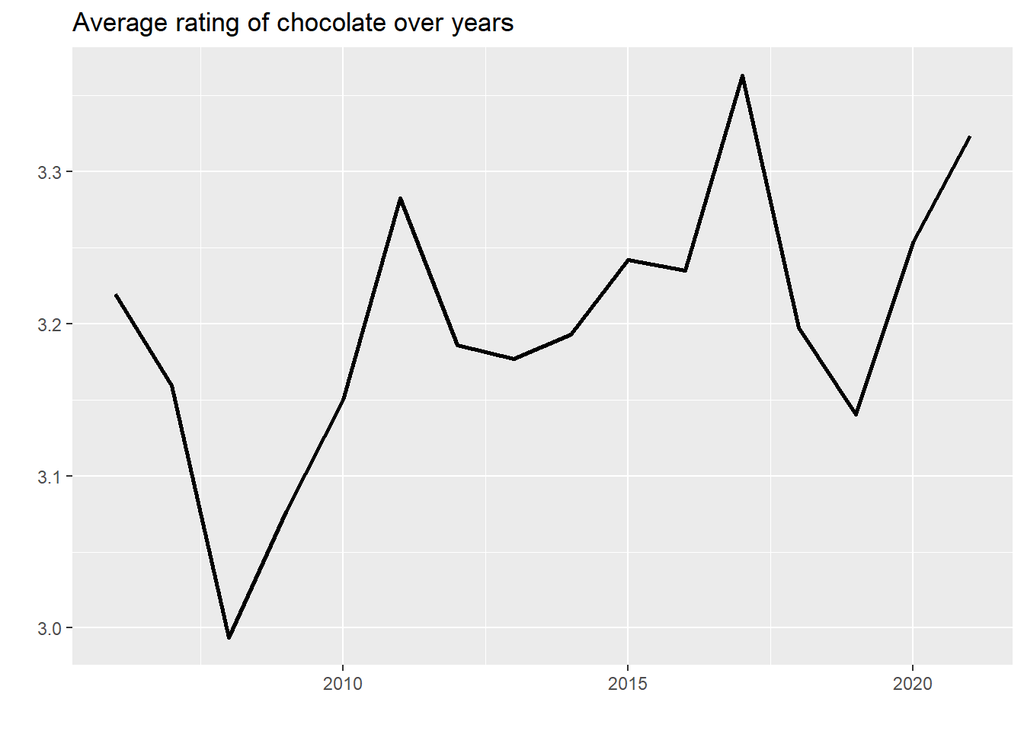

```r
tmp = data %>% group_by(year) %>% summarise(avg = mean(rating))

tmp %>%
  ggplot(aes(x = year, y = avg)) +
  geom_line(size = 1) +
  labs(title="Average rating of chocolate over years", x = "", y = "")
```

```r
round(cor(data$year, data$rating), 2)
```

```
## [1] 0.09
```

```r
round(cor(tmp$year, tmp$avg), 2)
```

```
## [1] 0.54
```

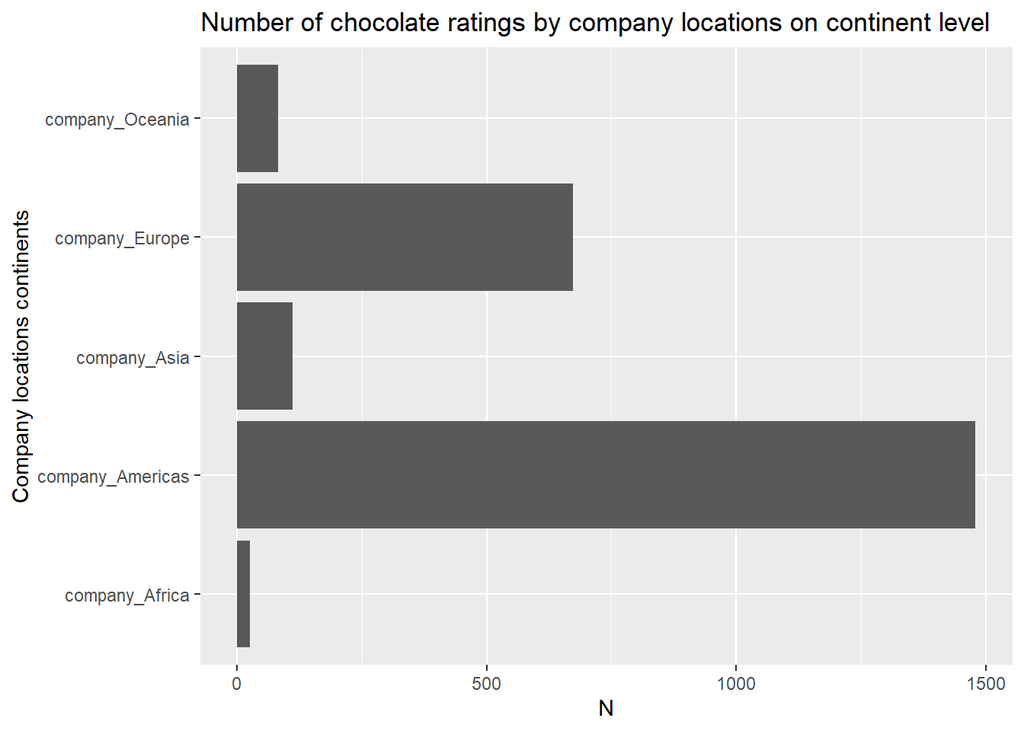

```r
data %>%
  summarise_at(c("company_Africa", "company_Americas", "company_Asia", "company_Europe", "company_Oceania"), sum) %>%
  gather() %>%
  ggplot(aes(x=key, y=value)) +
  geom_bar(stat = "identity") +
  coord_flip() +
  labs(title="Number of chocolate ratings by company locations on continent level", x = "Company locations continents", y = "N")
```

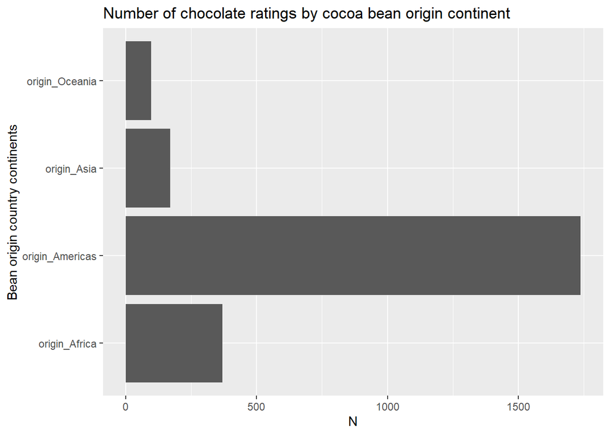

```r
data %>%
  summarise_at(c("origin_Africa", "origin_Americas", "origin_Asia", "origin_Oceania"), sum) %>%
  gather() %>%
  ggplot(aes(x=key, y=value)) +
  geom_bar(stat = "identity") +
  coord_flip() +
  labs(title="Number of chocolate ratings by cocoa bean origin continent", x = "Bean origin country continents", y = "N")
```

Notes:

1. While the low correlation between year and rating suggest no linear relationship between in the data set, the aggregation to year level indicates a more strong relationship. Judges seem to rate chocolates higher over time.
2. While the aggregation did not solve the skewness of our data towards America, its variance in terms of distinct values is certainly reduced. This will lead to a model which more easy to interpret.

After all this, can conclude the section with centering and scaling the data.

```r
data = data %>% select(!key) %>% scale() %>% data.frame()
# summary(data)
```

# A linear model fitted and evaluated

```r
model = lm(rating ~ year + cocoa +
            company_Africa + company_Americas + company_Asia + company_Europe + company_Oceania +
            origin_Africa + origin_Americas + origin_Asia + origin_Oceania +
            count_characteristics + average_characteristics_rating +
            contains_beans + contains_cocoa_butter + contains_lecithin + contains_sugar + contains_sweetener + contains_salt + contains_vanilla + count_additional_ingredients,
          data)

summary(model)
```

```
##
## Call:
## lm(formula = rating ~ year + cocoa + company_Africa + company_Americas +
##     company_Asia + company_Europe + company_Oceania + origin_Africa +
##     origin_Americas + origin_Asia + origin_Oceania + count_characteristics +
##     average_characteristics_rating + contains_beans + contains_cocoa_butter +
##     contains_lecithin + contains_sugar + contains_sweetener +
##     contains_salt + contains_vanilla + count_additional_ingredients,
##     data = data)
##
## Residuals:
##     Min      1Q  Median      3Q     Max
## -4.5058 -0.6475  0.0147  0.6421  2.3948
##
## Coefficients: (3 not defined because of singularities)
##                                  Estimate Std. Error t value Pr(>|t|)
## (Intercept)                     7.355e-16  1.979e-02   0.000   1.0000
## year                            4.023e-02  2.230e-02   1.804   0.0714 .
## cocoa                          -1.343e-01  2.168e-02  -6.193 6.94e-10 ***
## company_Africa                 -3.719e-02  2.393e-02  -1.554   0.1203
## company_Americas               -7.556e-02  5.851e-02  -1.291   0.1967
## company_Asia                   -2.830e-02  3.260e-02  -0.868   0.3853
## company_Europe                 -1.825e-02  5.593e-02  -0.326   0.7442
## company_Oceania                        NA         NA      NA       NA
## origin_Africa                   1.958e-02  4.342e-02   0.451   0.6520
## origin_Americas                 1.742e-02  4.931e-02   0.353   0.7239
## origin_Asia                    -1.176e-02  3.483e-02  -0.338   0.7357
## origin_Oceania                         NA         NA      NA       NA
## count_characteristics          -8.176e-02  1.997e-02  -4.095 4.37e-05 ***
## average_characteristics_rating  1.809e-02  2.072e-02   0.873   0.3827
## contains_beans                  1.489e-01  7.399e-02   2.012   0.0443 *
## contains_cocoa_butter           3.303e-02  2.240e-02   1.475   0.1404
## contains_lecithin              -2.159e-02  2.243e-02  -0.962   0.3360
## contains_sugar                 -1.881e-02  1.001e-01  -0.188   0.8509
## contains_sweetener             -8.977e-02  7.198e-02  -1.247   0.2125
## contains_salt                  -1.685e-02  2.133e-02  -0.790   0.4296
## contains_vanilla               -1.323e-01  2.261e-02  -5.850 5.60e-09 ***
## count_additional_ingredients           NA         NA      NA       NA
## ---
## Signif. codes:  0 '***' 0.001 '**' 0.01 '*' 0.05 '.' 0.1 ' ' 1
##
## Residual standard error: 0.9645 on 2355 degrees of freedom
## Multiple R-squared:  0.07688,    Adjusted R-squared:  0.06982
## F-statistic:  10.9 on 18 and 2355 DF,  p-value: < 2.2e-16
```

```r
round(anova(model), 4)
```

```
## Analysis of Variance Table
##
## Response: rating
##                                  Df  Sum Sq Mean Sq F value Pr(>F)
## year                              1   19.01  19.008 20.4345 <2e-16 ***
## cocoa                             1   43.90  43.898 47.1934 <2e-16 ***
## company_Africa                    1    3.63   3.625  3.8974 0.0485 *
## company_Americas                  1    5.53   5.532  5.9476 0.0148 *
## company_Asia                      1    4.03   4.029  4.3317 0.0375 *
## company_Europe                    1    0.49   0.495  0.5318 0.4659
## origin_Africa                     1    0.09   0.086  0.0925 0.7610
## origin_Americas                   1    0.73   0.726  0.7803 0.3771
## origin_Asia                       1    0.04   0.035  0.0378 0.8459
## count_characteristics             1   14.13  14.135 15.1957 0.0001 ***
## average_characteristics_rating    1    1.94   1.943  2.0886 0.1485
## contains_beans                    1   34.72  34.722 37.3288 <2e-16 ***
## contains_cocoa_butter             1    0.04   0.039  0.0422 0.8373
## contains_lecithin                 1    4.12   4.122  4.4317 0.0354 *
## contains_sugar                    1   15.55  15.548 16.7150 <2e-16 ***
## contains_sweetener                1    1.61   1.611  1.7324 0.1882
## contains_salt                     1    1.05   1.049  1.1280 0.2883
## contains_vanilla                  1   31.83  31.834 34.2233 <2e-16 ***
## Residuals                      2355 2190.56   0.930
## ---
## Signif. codes:  0 '***' 0.001 '**' 0.01 '*' 0.05 '.' 0.1 ' ' 1
```

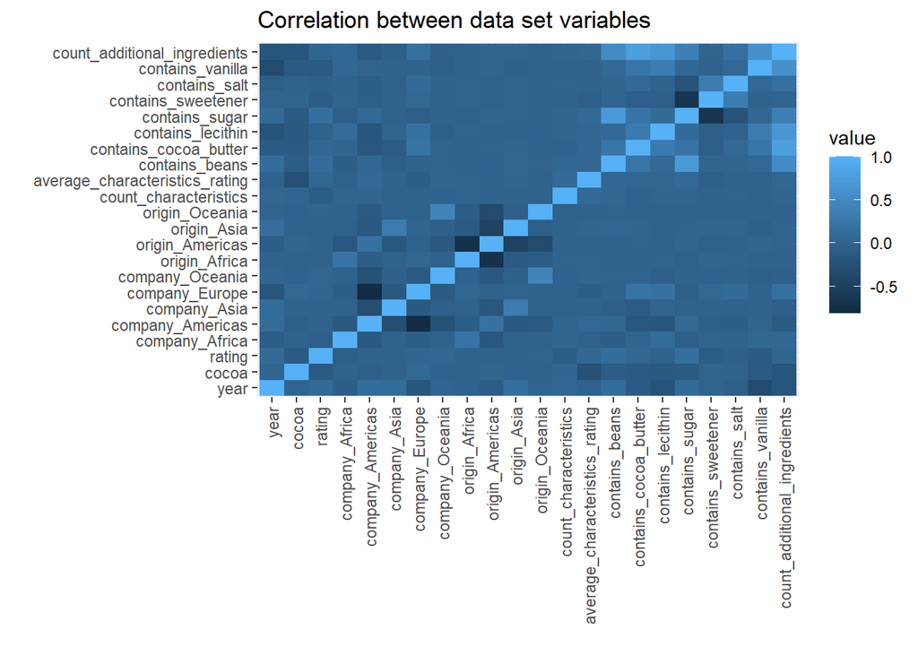

```r
corr = melt(round(cor(data), 2))
ggplot(data = corr, aes(x=Var1, y=Var2, fill=value)) +
  geom_tile() +
  theme(axis.text.x = element_text(angle = 90, vjust = 0.5, hjust=1)) +
  labs(title="Correlation between data set variables", x = "", y = "")
```

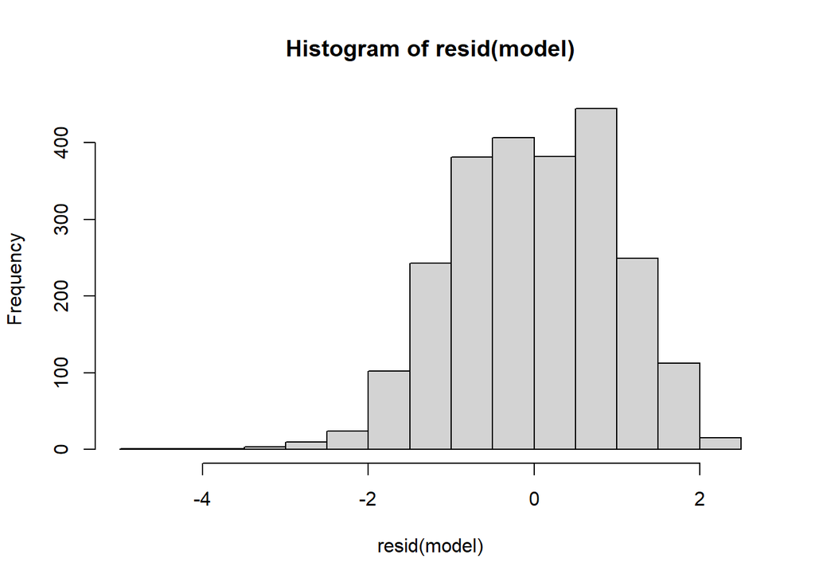

```r
hist(resid(model))
```

```r
shapiro.test(resid(model))
```

```
##
##  Shapiro-Wilk normality test
##
## data:  resid(model)
## W = 0.99199, p-value = 3.606e-10
```

```r
car::ncvTest(model)
```

```
## Non-constant Variance Score Test
## Variance formula: ~ fitted.values
## Chisquare = 27.1998, Df = 1, p = 1.8348e-07
```

In the end, tried to fit a linear model to the data set, trying to see if there are variables whose linear combination explain certain ratings. The model reported the following with varying significance:

- year
- cocoa
- count_characteristics
- contains_beans
- contains_vanilla

These variables were also reported as significant in the ANOVA, meaning that they indeed explain a proportion of variance among the ratings.

However, in the end the model residuals’ statistics indicates that fitting a linear model is not appropriate to this set of variables because 1) the residuals are not normally distributed - which is visible on the histogram and Shapiro-Wilk test returned a p-value below of the usual 0.05 tolerance; and because 2) the residuals are also not homoscedastic, proven by the Breusch–Pagan test which returned also a low p-value.